# Clustering for scRNA-seq data of CMC D1

Lihui Lin

July 26, 2018

# Clustering CMC D1 data

Here we use two strategies to clustering:  
**1. Seurat:** Detect communitis in Shared Nearest Neighbors network;  
**2. SIMLR:** Single-cell Interpretation via Multi-kernel LeaRning.  
SIMLR is often much precise but slower than Seurat.

## Look through the data

Violin plot below shows:  
- nGene: Number of genes detected (UMI>0) in each cell.  
- nUMI: Number of Unique Molecular Identity identified in each cell.  
- percent.mito: Percentage of mitochondrial genes UMIs in all total UMIs.  
*Note that large number of cells express high level of mitochondrial genes. Is it a reasonable phenomenon for cardiac muscle cells?*

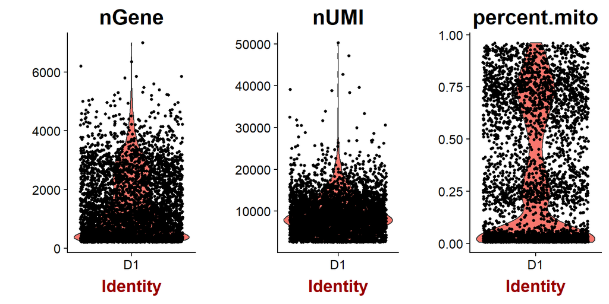

## Seurat clustering

The cells were clustering using [Seurat,2016](https://satijalab.org/seurat/get_started.html). The top 8 PCs were used as imput. No mitochondrion genes were detected as HVG.

Determine statistically significant principal components. We select top 8 pcs for clustering.

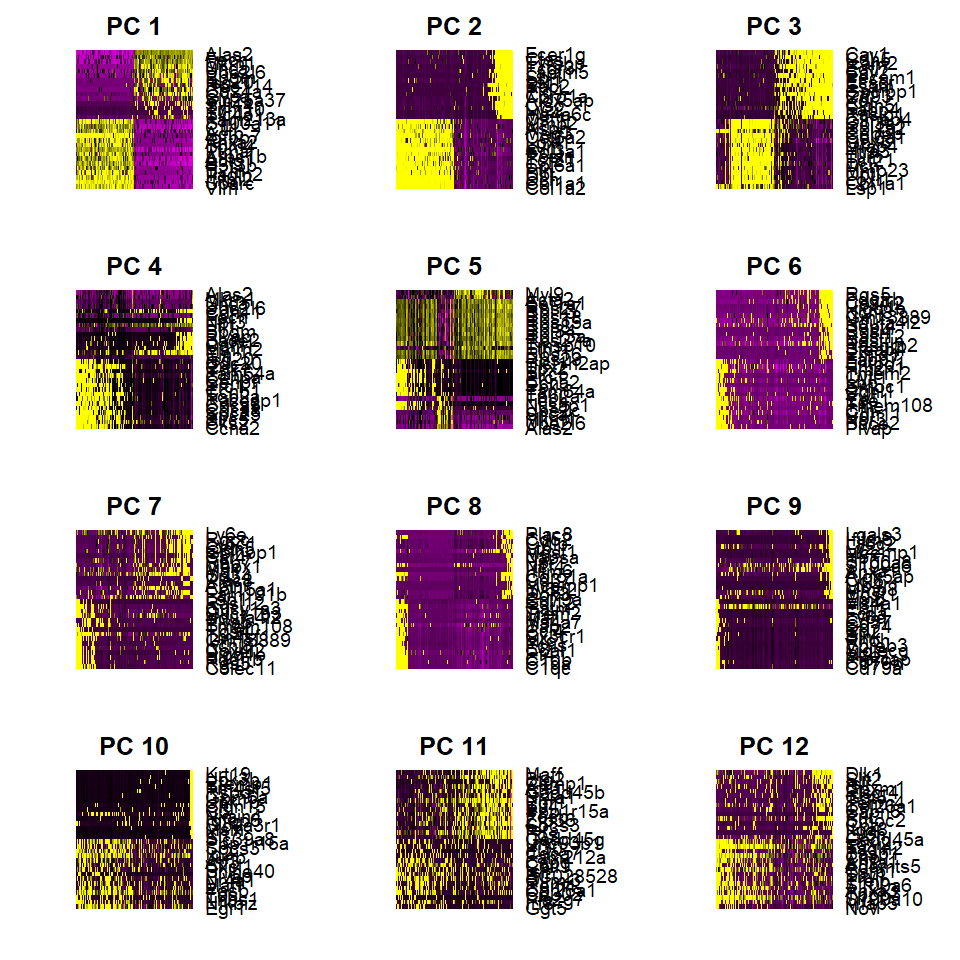

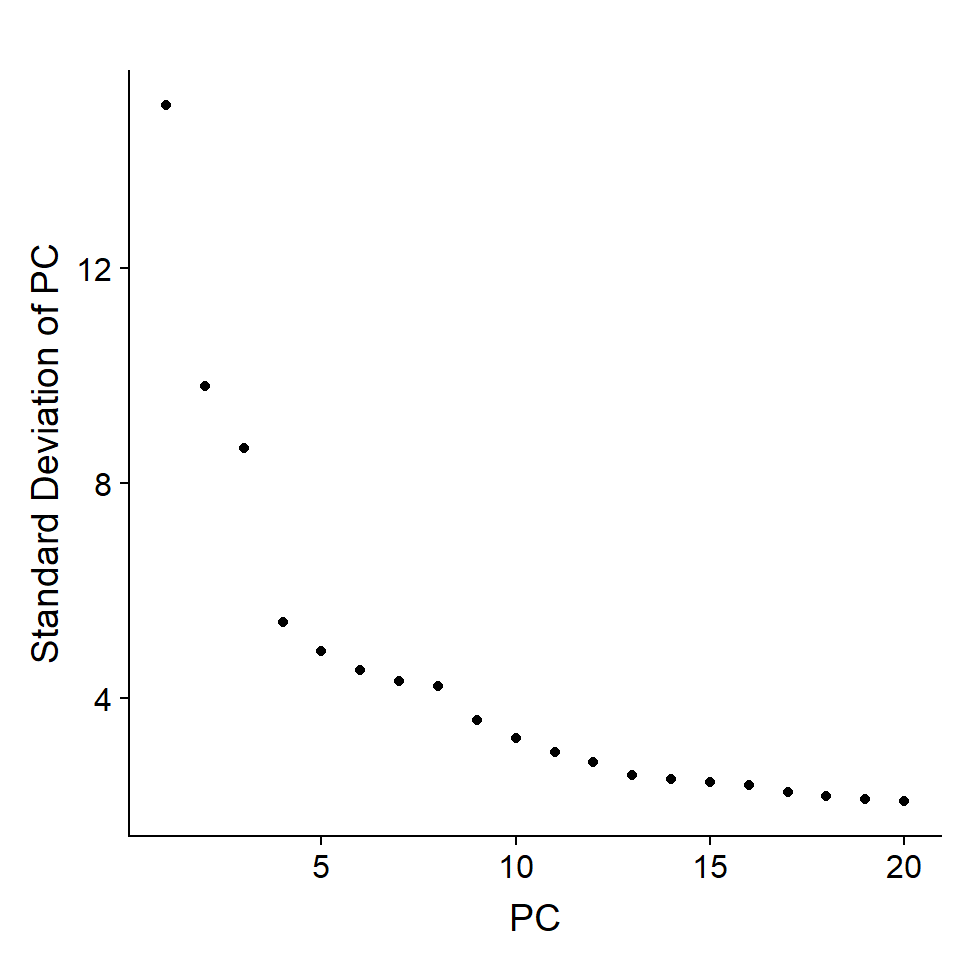

tSNE and UMAP are two non-linear dimention reduction algorithm. The clustering results of **Seurat** are showed. *(Resolution=0.2*)

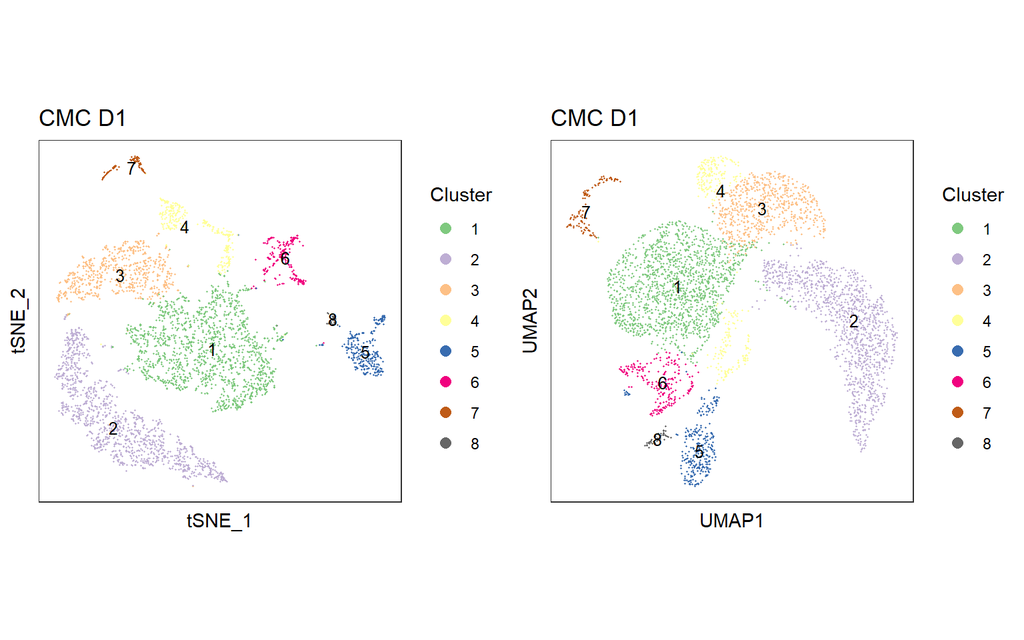

Cardica myoblast markers and hemoglobin

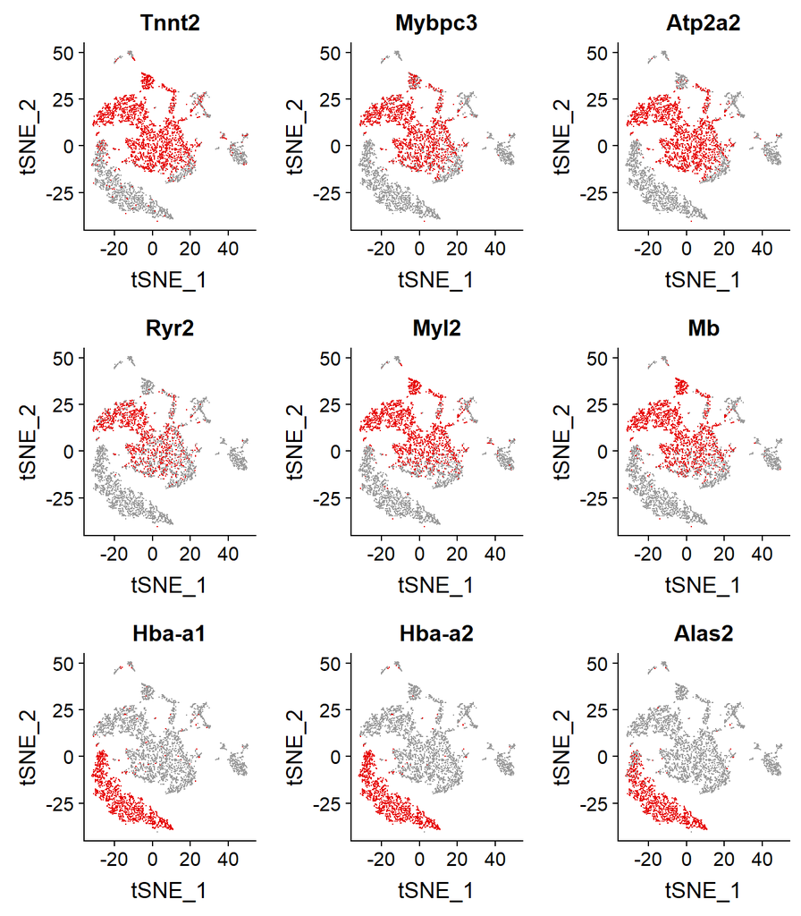

Hematopoietic markers

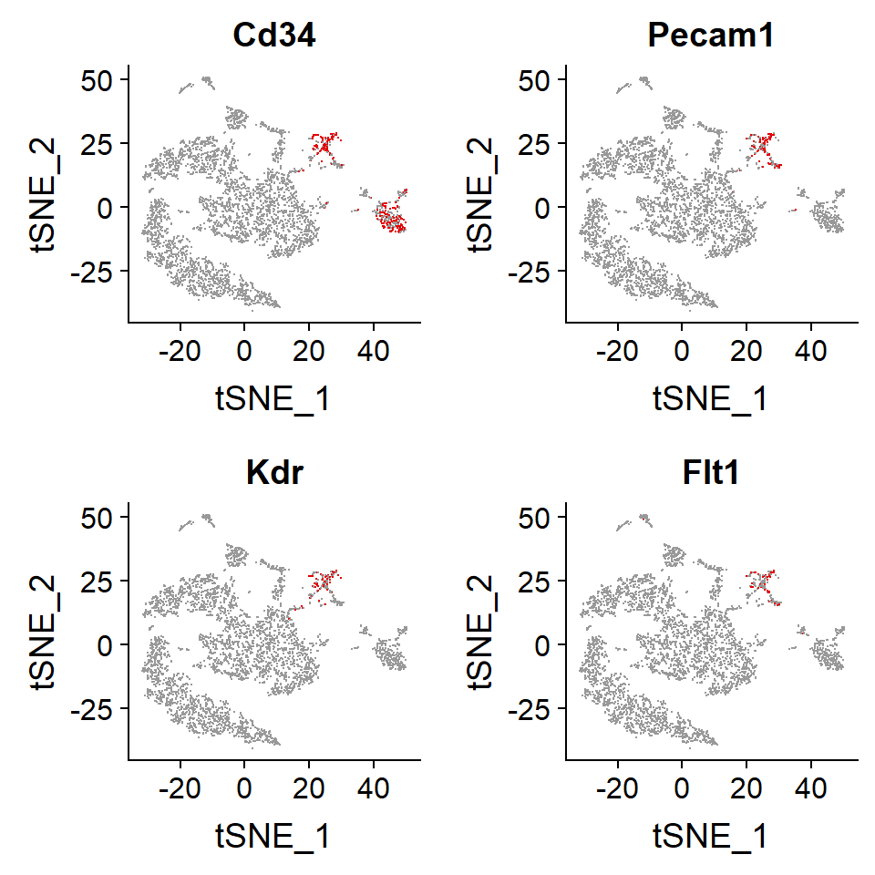

### Find markers in each group

Top 10 markers of each cluster.

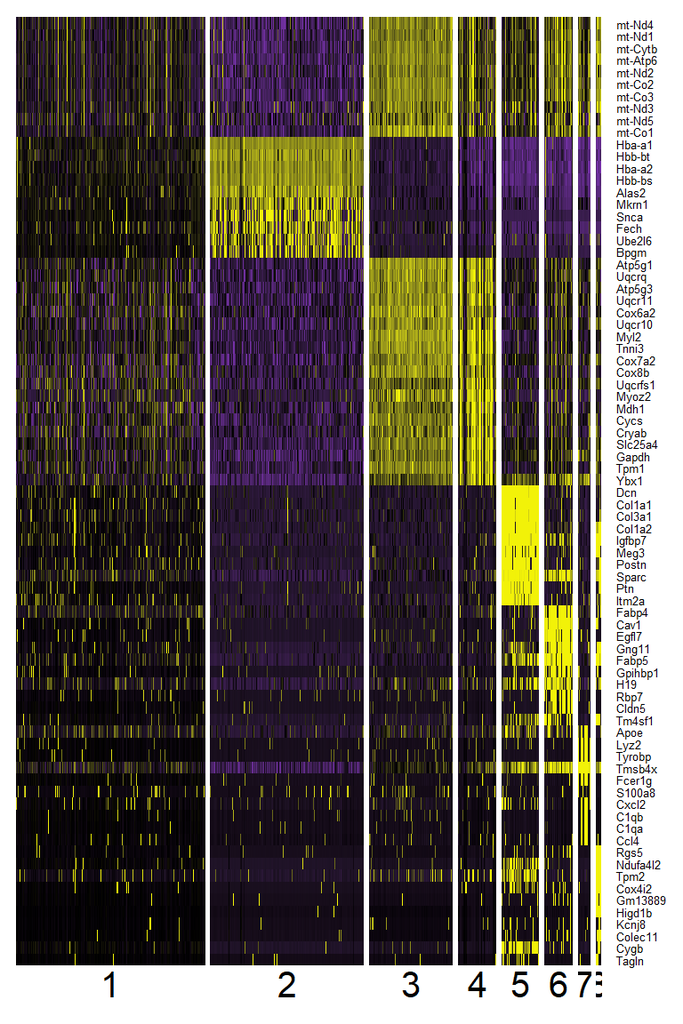

Differentially expression stats.

|  | p_val | avg_logFC | pct.1 | pct.2 | p_val_adj | cluster | gene |
| --- | --- | --- | --- | --- | --- | --- | --- |
| mt-Nd4 | 0 | 1.99559635238648 | 1 | 0.991 | 0 | 1 | mt-Nd4 |
| mt-Nd1 | 0 | 1.98779179323915 | 1 | 1 | 0 | 1 | mt-Nd1 |
| mt-Cytb | 0 | 1.94764702627785 | 1 | 0.999 | 0 | 1 | mt-Cytb |
| mt-Atp6 | 0 | 1.85969324810236 | 1 | 1 | 0 | 1 | mt-Atp6 |
| mt-Nd2 | 0 | 1.83260146716282 | 1 | 0.921 | 0 | 1 | mt-Nd2 |
| mt-Co2 | 0 | 1.83172984535523 | 1 | 0.995 | 0 | 1 | mt-Co2 |
| mt-Co3 | 0 | 1.82298349651114 | 1 | 1 | 0 | 1 | mt-Co3 |
| mt-Nd3 | 0 | 1.82151185379899 | 0.997 | 0.702 | 0 | 1 | mt-Nd3 |
| mt-Nd5 | 0 | 1.45344751589451 | 0.997 | 0.792 | 0 | 1 | mt-Nd5 |
| mt-Co1 | 0 | 1.3704648733205 | 1 | 0.998 | 0 | 1 | mt-Co1 |

[output cut: 4454 more lines]

### Enrichment

Reactome pathway

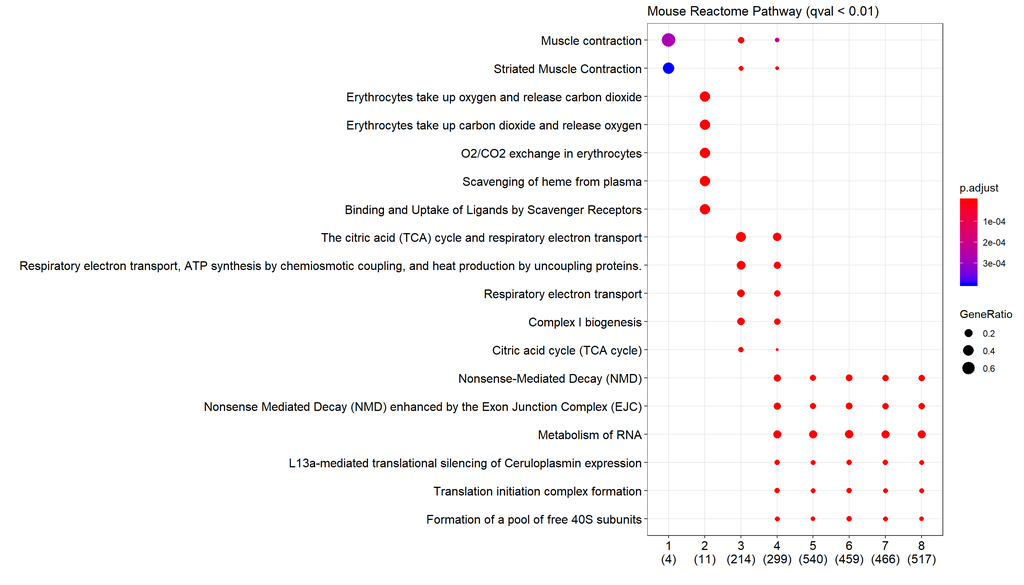

|  | Cluster | ID | Description | GeneRatio | BgRatio | pvalue | p.adjust | qvalue | geneID | Count |
| --- | --- | --- | --- | --- | --- | --- | --- | --- | --- | --- |
| 1 | 1 | R-MMU-397014 | Muscle contraction | 3/4 | 173/9315 | 2.48447429141896e-05 | 0.000273292172056086 | 7.84570828869145e-05 | Myh6/Atp2a2/Mybpc3 | 3 |
| 2 | 1 | R-MMU-390522 | Striated Muscle Contraction | 2/4 | 33/9315 | 7.27053921750581e-05 | 0.000399879656962819 | 0.000114797987644829 | Myh6/Mybpc3 | 2 |
| 3 | 2 | R-MMU-1247673 | Erythrocytes take up oxygen and release carbon dioxide | 4/11 | 10/9315 | 2.20254545004155e-10 | 7.48865453014127e-09 | 3.47770334217087e-09 | Hba-a1/Hbb-bt/Hba-a2/Hbb-bs | 4 |
| 4 | 2 | R-MMU-1237044 | Erythrocytes take up carbon dioxide and release oxygen | 4/11 | 14/9315 | 1.04735530156192e-09 | 1.18700267510351e-08 | 5.51239632401013e-09 | Hba-a1/Hbb-bt/Hba-a2/Hbb-bs | 4 |
| 5 | 2 | R-MMU-1480926 | O2/CO2 exchange in erythrocytes | 4/11 | 14/9315 | 1.04735530156192e-09 | 1.18700267510351e-08 | 5.51239632401013e-09 | Hba-a1/Hbb-bt/Hba-a2/Hbb-bs | 4 |
| 6 | 2 | R-MMU-2168880 | Scavenging of heme from plasma | 4/11 | 23/9315 | 9.21499022802746e-09 | 7.83274169382334e-08 | 3.63749614264242e-08 | Hba-a1/Hbb-bt/Hba-a2/Hbb-bs | 4 |
| 7 | 2 | R-MMU-2173782 | Binding and Uptake of Ligands by Scavenger Receptors | 4/11 | 40/9315 | 9.41359468101428e-08 | 6.40124438308971e-07 | 2.97271410979398e-07 | Hba-a1/Hbb-bt/Hba-a2/Hbb-bs | 4 |
| 8 | 2 | R-MMU-189451 | Heme biosynthesis | 2/11 | 11/9315 | 6.93293744757962e-05 | 0.000392866455362845 | 0.000182445722304727 | Alas2/Fech | 2 |
| 9 | 2 | R-MMU-189445 | Metabolism of porphyrins | 2/11 | 18/9315 | 0.000191993623506317 | 0.00093254045703068 | 0.000433068323698458 | Alas2/Fech | 2 |
| 10 | 3 | R-MMU-1428517 | The citric acid (TCA) cycle and respiratory electron transport | 74/214 | 136/9315 | 5.63253596667222e-89 | 3.00777420620296e-86 | 2.84591290947649e-86 | Atp5g3/Atp5e/Atp5k/Atp5o/Ndufv3/Atp5j2/Atp5c1/Atp5l/Ndufa3/N…… | 74 |

[output cut: 898 more lines]

## 2. SIMLR clustering

The cells were clustering using [SIMLR,2017](http://dx.doi.org/10.1038/nmeth.4207). The top 20 PCs were used as imput.

2-D embedding.

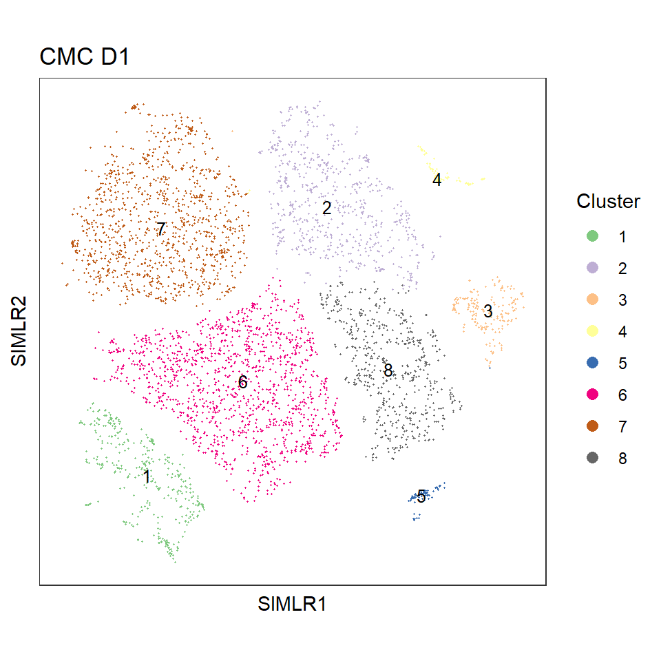

### Find markers in each group

Heatmap of the top 10 markers ranked by logFC using *bimod* test.

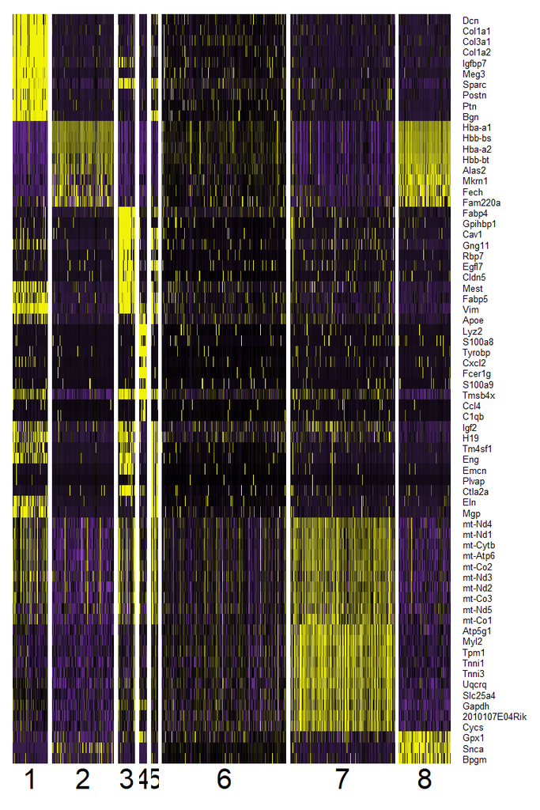

Differentially expression stats.

|  | p_val | avg_logFC | pct.1 | pct.2 | p_val_adj | cluster | gene |
| --- | --- | --- | --- | --- | --- | --- | --- |
| Dcn | 0 | 3.38328627895494 | 0.906 | 0.22 | 0 | 1 | Dcn |
| Col1a1 | 0 | 3.34896473675475 | 0.906 | 0.206 | 0 | 1 | Col1a1 |
| Col3a1 | 0 | 3.24614687455263 | 0.947 | 0.311 | 0 | 1 | Col3a1 |
| Col1a2 | 0 | 3.01564819183013 | 0.944 | 0.174 | 0 | 1 | Col1a2 |
| Igfbp7 | 0 | 2.93150297190441 | 0.994 | 0.254 | 0 | 1 | Igfbp7 |
| Meg3 | 0 | 2.92450183337435 | 0.942 | 0.118 | 0 | 1 | Meg3 |
| Sparc | 0 | 2.72109639978143 | 0.997 | 0.528 | 0 | 1 | Sparc |
| Postn | 0 | 2.65297774152197 | 0.914 | 0.223 | 0 | 1 | Postn |
| Ptn | 0 | 2.47016902272461 | 0.903 | 0.104 | 0 | 1 | Ptn |
| Bgn | 0 | 2.43661397761344 | 0.953 | 0.125 | 0 | 1 | Bgn |

[output cut: 3512 more lines]